# Multi-Species Fishery Model

This is a multi-species fishery model that allows us to reflect how quota baskets affect stock levels

### Our Model: Population Growth & Profit

1. **Stock Dynamic**: biomass of species $j$ at time $t$

$X_{j,t+1} = X_{j,t} + r_jX_{j,t}\times (1-{X_{j,t}\over K_j}) - H_{j,t}$

2. **Harvest**: Harvest of species $j$ at time $t$ ; Harvest of technology $i$ at time $t$ (Kat translation: the first one: how much fish of species j is caught using all different techs, and the second one: how much of all fish species is caught using tech i)

$$\begin{cases}
H_{j,t} = \sum_{i=1}^{techNum} q_{i,j}E_iX_{j,t}\\[2ex]
H_{i,t} = \sum_{j=1}^{speciesNum} q_{i,j}E_iX_{j,t}
\end{cases}$$

3. **Profit**: Profit of all technologies at time $t$

   $\pi_{t} = \sum_{i=1}^{techNum}[(\sum_{j=1}^{speciesNum} p_j \times q_{i,j}E_iX_{j,t}) - c_iE_i]$
4. **Present Value of Net Benefit (PVNB)**: sum of the present value of profits of all technologies for the whole study period

$PVNB=\sum_{t=1}^{year} [({1\over 1+\delta})^t \times \pi_{t}]$

*where,*

- *$X_0$ = initial population size*
- *$r$ = intrinsic growth rate*
- *$K$ = carrying capacity*
- *$q$ = catchability coefficient*
- *$E$ = fishing effort*
- *$p$ = price of 1 unit of fish*
- *$\pi$ = revenue*
- *$c$ = cost*
- *$\delta$ = discount rate*

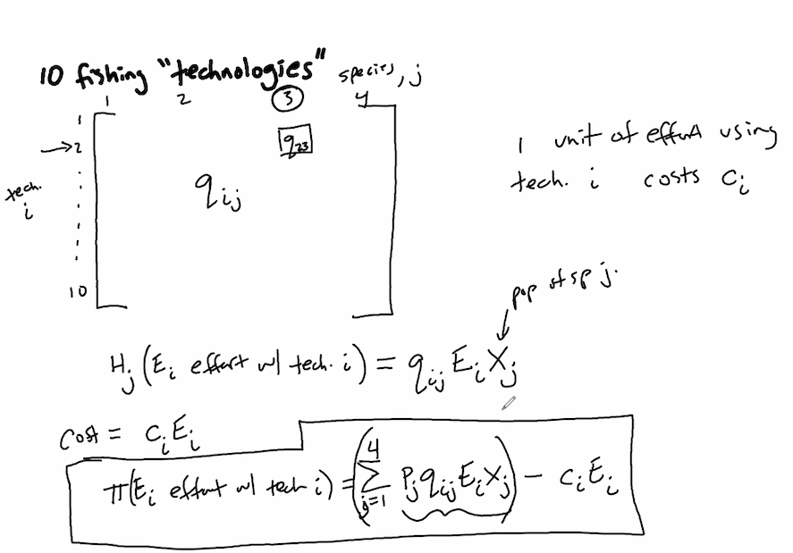

### Check Our Model for Single Species

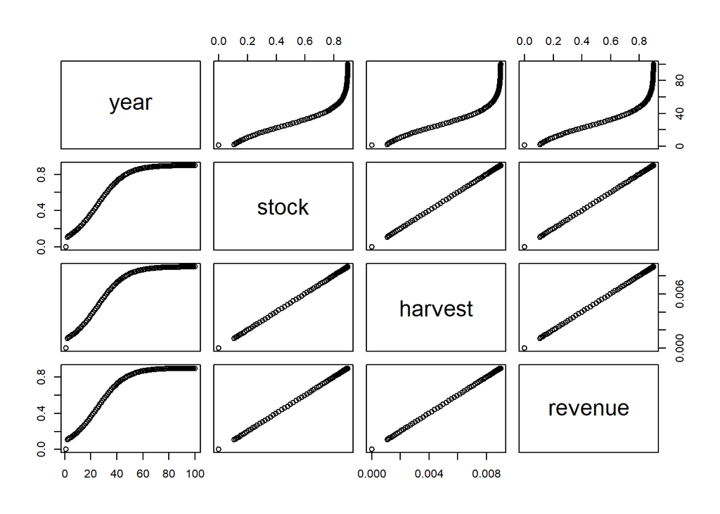

**Great, this works for a single species. Can we include this for multiple species?**

1. We will need to define parameters for each of these species.
2. Then, we can write a function that allows us to plug these parameters in as a list of values, as many times as we want.

### Calculate Profit for a multi-species and multi-technoligy model

We will keep our model simple first. Here we create a model of 4 technologies and 4 species. The price of fish only depends on species (will add in more attributes later).

1. Initial Parameters for Species

   | species | r | K | X0 | p | c | delta | rho |
   | --- | --- | --- | --- | --- | --- | --- | --- |
   | 1 | 1.0 | 1.0 | 0.5 | 200 | 1 | 0.05 | 0.952381 |
   | 2 | 0.5 | 1.2 | 0.6 | 200 | 1 | 0.05 | 0.952381 |
   | 3 | 0.4 | 2.0 | 1.0 | 200 | 1 | 0.05 | 0.952381 |
   | 4 | 0.9 | 3.0 | 1.0 | 200 | 1 | 0.05 | 0.952381 |

2. Catchability Coefficient Matrix

Catchability Coefficient Matrix

|  | species 1 | species 2 | species 3 | species 4 |
| --- | --- | --- | --- | --- |
| tech 1 | 0.05 | 0.04 | 0.000 | 0.00 |
| tech 2 | 0.05 | 0.05 | 0.011 | 0.01 |
| tech 3 | 0.07 | 0.05 | 0.050 | 0.02 |
| tech 4 | 0.07 | 0.05 | 0.050 | 0.05 |

3. Calculate Stock Dynamics

Stock Dynamic

|  | stock 1 | stock 2 | stock 3 | stock 4 |
| --- | --- | --- | --- | --- |
| year 1 | 0.5000000 | 0.6000000 | 1.000000 | 1.000000 |
| year 2 | 0.6900000 | 0.6930000 | 1.144500 | 1.560000 |
| year 3 | 0.8211000 | 0.7735613 | 1.276804 | 2.171520 |
| year 4 | 0.8694628 | 0.8375215 | 1.390618 | 2.624378 |
| year 5 | 0.8786245 | 0.8844501 | 1.482922 | 2.815135 |
| year 11 | 0.8800000 | 0.9674883 | 1.699147 | 2.866666 |
| year 12 | 0.8800000 | 0.9693070 | 1.707083 | 2.866667 |
| year 13 | 0.8800000 | 0.9703947 | 1.712347 | 2.866667 |
| year 14 | 0.8800000 | 0.9710438 | 1.715824 | 2.866667 |
| year 15 | 0.8800000 | 0.9714307 | 1.718115 | 2.866667 |

4. Simulate Harvest  
   4.1 Simulate the harvest for each species

Harvest for each species in each year

|  | stock.1 | stock.2 | stock.3 | stock.4 |
| --- | --- | --- | --- | --- |
| 1 | 0.0600000 | 0.0570000 | 0.0555000 | 0.0400000 |
| 2 | 0.0828000 | 0.0658350 | 0.0635197 | 0.0624000 |
| 3 | 0.0985320 | 0.0734883 | 0.0708626 | 0.0868608 |
| 4 | 0.1043355 | 0.0795645 | 0.0771793 | 0.1049751 |
| 5 | 0.1054349 | 0.0840228 | 0.0823022 | 0.1126054 |
| 11 | 0.1056000 | 0.0919114 | 0.0943026 | 0.1146666 |
| 12 | 0.1056000 | 0.0920842 | 0.0947431 | 0.1146667 |
| 13 | 0.1056000 | 0.0921875 | 0.0950352 | 0.1146667 |
| 14 | 0.1056000 | 0.0922492 | 0.0952282 | 0.1146667 |
| 15 | 0.1056000 | 0.0922859 | 0.0953554 | 0.1146667 |

4.2 Simulate the harvest for each technology

Harvest for each technology in each year

|  | tech 1 | tech 2 | tech 3 | tech 4 |
| --- | --- | --- | --- | --- |
| year 1 | 0.0245000 | 0.0380000 | 0.0675000 | 0.0825000 |
| year 2 | 0.0311100 | 0.0486698 | 0.0856875 | 0.1090875 |
| year 3 | 0.0359987 | 0.0577466 | 0.1017128 | 0.1342856 |
| year 4 | 0.0384870 | 0.0634449 | 0.1123784 | 0.1517441 |
| year 5 | 0.0396546 | 0.0663086 | 0.1180875 | 0.1603145 |
| year 11 | 0.0413498 | 0.0698658 | 0.1261325 | 0.1691325 |
| year 12 | 0.0413861 | 0.0699550 | 0.1263764 | 0.1693764 |
| year 13 | 0.0414079 | 0.0700111 | 0.1265352 | 0.1695352 |
| year 14 | 0.0414209 | 0.0700465 | 0.1266384 | 0.1696384 |
| year 15 | 0.0414286 | 0.0700687 | 0.1267053 | 0.1697053 |

5. Calculate the profit generated by each technology

Profit for each technology

|  | tech.1 | tech.2 | tech.3 | tech.4 | total_profit |
| --- | --- | --- | --- | --- | --- |
| year 1 | 4.400000 | 7.10000 | 13.00000 | 16.00000 | 40.50000 |
| year 2 | 5.722000 | 9.23395 | 16.63750 | 21.31750 | 52.91095 |
| year 3 | 6.699745 | 11.04931 | 19.84257 | 26.35713 | 63.94875 |
| year 4 | 7.197400 | 12.18898 | 21.97569 | 29.84882 | 71.21089 |
| year 5 | 7.430923 | 12.76172 | 23.11750 | 31.56291 | 74.87305 |
| year 11 | 7.769953 | 13.47317 | 24.72651 | 33.32651 | 79.29614 |
| year 12 | 7.777228 | 13.49099 | 24.77528 | 33.37528 | 79.41879 |
| year 13 | 7.781579 | 13.50222 | 24.80704 | 33.40704 | 79.49788 |
| year 14 | 7.784175 | 13.50929 | 24.82767 | 33.42767 | 79.54881 |
| year 15 | 7.785723 | 13.51375 | 24.84106 | 33.44106 | 79.58159 |

6. Calculate PVNB

**The calculated PVNB is 771.8388187.**